# Take-home Assignment #1

Felix Lennert

handed out on 2020-06-29; to be handed in on 2020-07-06 at latest

Dear student,

This is the first take-home assignment for the course “Big Data Analysis with R.” You can team up with one of your peers and work on it together. I am absolutely sure that it will challenge you and this is definitely intended. If you have questions, reach out whenever. Seriously, whenever. So far, very few of you have done so. Therefore, I have no clue how good or bad it is going for you.

Well, let’s go in medias res. The dataset you will work with is from a tidy Tuesday challenge. I will not provide you the source right now, because then you could just simply look up the solution online. However, if you are stuck, you can try to search for it. To make sure that you have understood what you are doing, I want you to add comments next to your code, i.e., by inserting a ‘#’ on the right of the code and briefly describing why this command is necessary. You can also describe what the chunks are doing in the Markdown file between chunks.

1. Acquire the dataset by running the following chunk. Install the missing packages first if necessary. I commented the code for you to show you some web-scraping and how you should comment your code.

```r
library(rvest)
library(tidyverse)
url <- "https://www.nu3.de/blogs/nutrition/food-carbon-footprint-index-2018" # url to scrape

# scrape the website
url_html <- read_html(url) # read the page

# extract the HTML table
whole_table <- url_html %>%
  html_nodes('table') %>% # select table
  html_table(fill = TRUE) %>% # parse it to date frame
  .[[1]] # pull out the data frame

table_content <- whole_table %>%
  select(-X1) %>% # remove redundant column
  filter(!dplyr::row_number() %in% 1:3) # remove redundant rows

raw_headers <- url_html %>%
  html_nodes(".thead-icon") %>% # select element
  html_attr('title') # pull out column names

tidy_bottom_header <- raw_headers[28:length(raw_headers)]

raw_middle_header <- raw_headers[17:27]

tidy_headers <- c( # fix headers
  rep(raw_middle_header[1:7], each = 2),
  "animal_total",
  rep(raw_middle_header[8:length(raw_middle_header)], each = 2),
  "non_animal_total",
  "country_total")

combined_colnames <- paste(tidy_headers, tidy_bottom_header, sep = ';') # create column names
colnames(table_content) <- c("Country", combined_colnames) # add column names
table_content_tbl <- as_tibble(table_content)
table_content_tbl
```

```
## # A tibble: 130 x 26
##    Country `Pork;Supplied … `Pork;Kg CO2/pe… `Poultry;Suppli… `Poultry;Kg CO2…
##    <chr>   <chr>            <chr>            <chr>            <chr>
##  1 Argent… 10.51            37.20            38.66            41.53
##  2 Austra… 24.14            85.44            46.12            49.54
##  3 Albania 10.88            38.51            13.23            14.21
##  4 Iceland 21.69            76.77            26.87            28.86
##  5 New Ze… 22.29            78.90            34.98            37.58
##  6 USA     27.64            97.83            50.01            53.72
##  7 Uruguay 16.84            59.61            27.45            29.49
##  8 Luxemb… 43.58            154.25           21.37            22.96
##  9 Brazil  12.60            44.60            45.00            48.34
## 10 Kazakh… 10.36            36.67            18.38            19.74
## # … with 120 more rows, and 21 more variables: `Beef;Supplied for Consumption
## #   (kg/person/year)` <chr>, `Beef;Kg CO2/person/year` <chr>, `Lamb &
## #   Goat;Supplied for Consumption (kg/person/year)` <chr>, `Lamb & Goat;Kg
## #   CO2/person/year` <chr>, `Fish;Supplied for Consumption
## #   (kg/person/year)` <chr>, `Fish;Kg CO2/person/year` <chr>, `Eggs;Supplied
## #   for Consumption (kg/person/year)` <chr>, `Eggs;Kg CO2/person/year` <chr>,
## #   `Milk - inc. cheese;Supplied for Consumption (kg/person/year)` <chr>, `Milk
## #   - inc. cheese;Kg CO2/person/year` <chr>, `animal_total;Kg
## #   CO2/person/year` <chr>, `Wheat and Wheat Products;Supplied for Consumption
## #   (kg/person/year)` <chr>, `Wheat and Wheat Products;Kg
## #   CO2/person/year` <chr>, `Rice;Supplied for Consumption
## #   (kg/person/year)` <chr>, `Rice;Kg CO2/person/year` <chr>,
## #   `Soybeans;Supplied for Consumption (kg/person/year)` <chr>, `Soybeans;Kg
## #   CO2/person/year` <chr>, `Nuts inc. Peanut Butter;Supplied for Consumption
## #   (kg/person/year)` <chr>, `Nuts inc. Peanut Butter;Kg
## #   CO2/person/year` <chr>, `non_animal_total;Kg CO2/person/year` <chr>,
## #   `country_total;Kg CO2/person/year` <chr>
```

2. Make the dataset tidy. Ask yourself the following questions: which variables does it contain? How can I put them into separate columns?
3. Change the column names so that they do not have to be surrounded by backticks (i.e., they should only consist of lowercase characters, numbers, and underscores).
4. Coerce variables to factors (if it makes sense).

```r
table_content_tbl_tidy <- table_content_tbl %>%
  pivot_longer(-Country, names_to = "type", values_to = "value") %>%
  separate(type, into = c("food", "type"), sep = ";") %>%
  pivot_wider(names_from = type, values_from = value) %>%
  drop_na() %>%
  select(country = Country,
         food_type = food,
         kg_consumption = `Supplied for Consumption (kg/person/year)`,
         kg_co2 = `Kg CO2/person/year`) %>%
  mutate(country = as_factor(country),
         food_type = as_factor(food_type),
         kg_consumption = as.numeric(kg_consumption),
         kg_co2 = as.numeric(kg_co2))
```

5. Visualize your dataset with `ggplot2`.
   1. A scatter plot with `consumption` on the x and `kg_co2` on the y axis. Color the dots according to `country`.

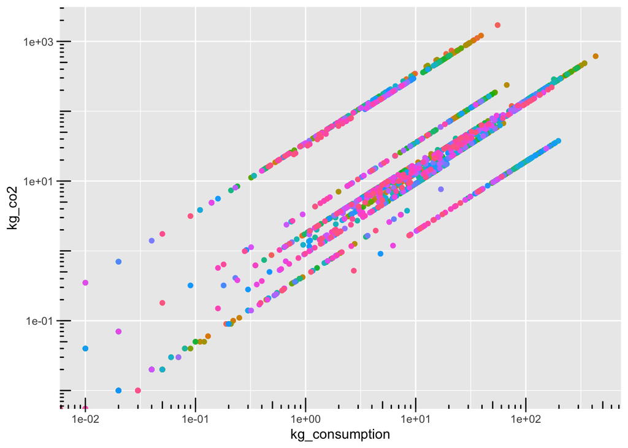

```
b. A smoothed line with the same variables (no country-specific color coding though).
```

```r
table_content_tbl_tidy %>% ggplot() +
  geom_point(aes(x = kg_consumption, y = kg_co2, color = country)) +
  scale_x_log10() +
  scale_y_log10() +
  annotation_logticks() +
  theme(legend.position = "none")
```

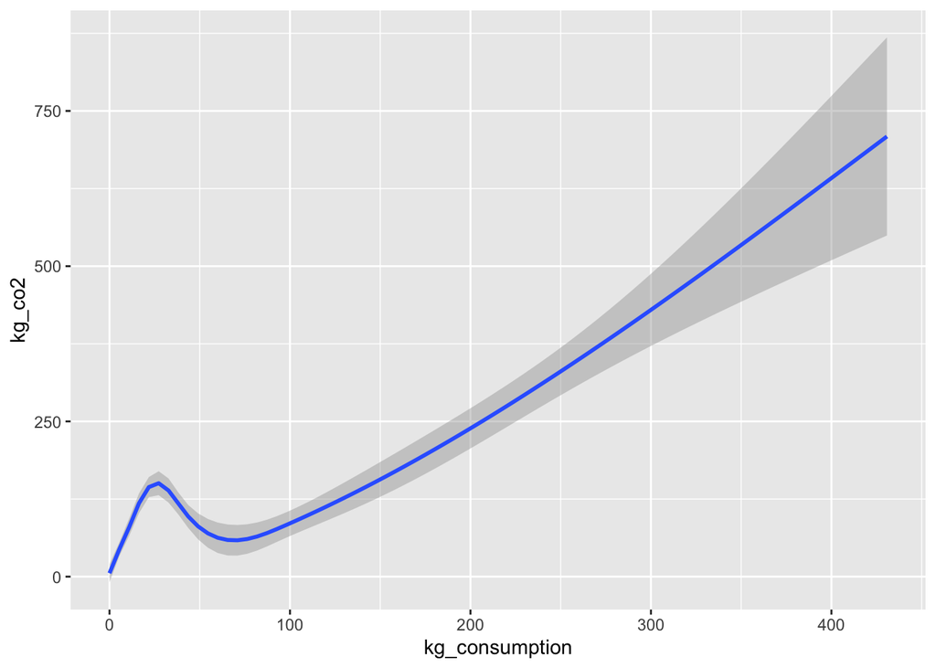

```
c. Faceted graphs according to type of food.
```

```r
table_content_tbl_tidy %>% ggplot() +
  geom_smooth(aes(x = kg_consumption, y = kg_co2))
```

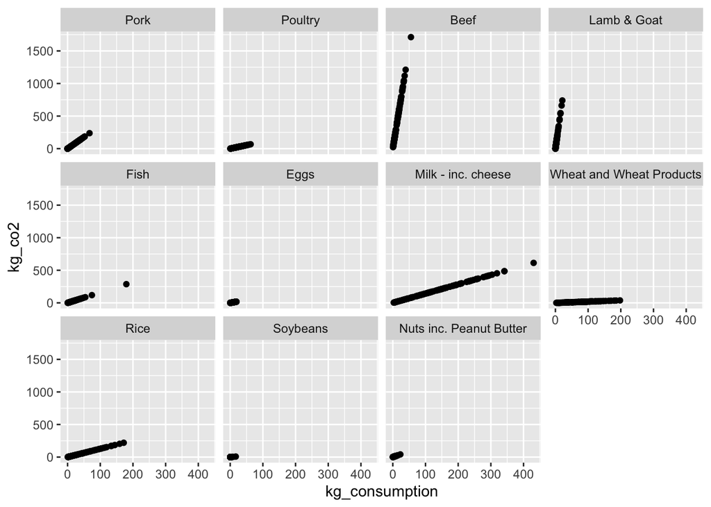

```
d. A scatter plot with the sum of supply for consumption per country (x axis) and total CO2 emissions per country (y axis). Color the dots as in (a).
```

```r
table_content_tbl_tidy %>% ggplot() +
  geom_point(aes(x = kg_consumption, y = kg_co2)) +
  facet_wrap(~food_type)
```

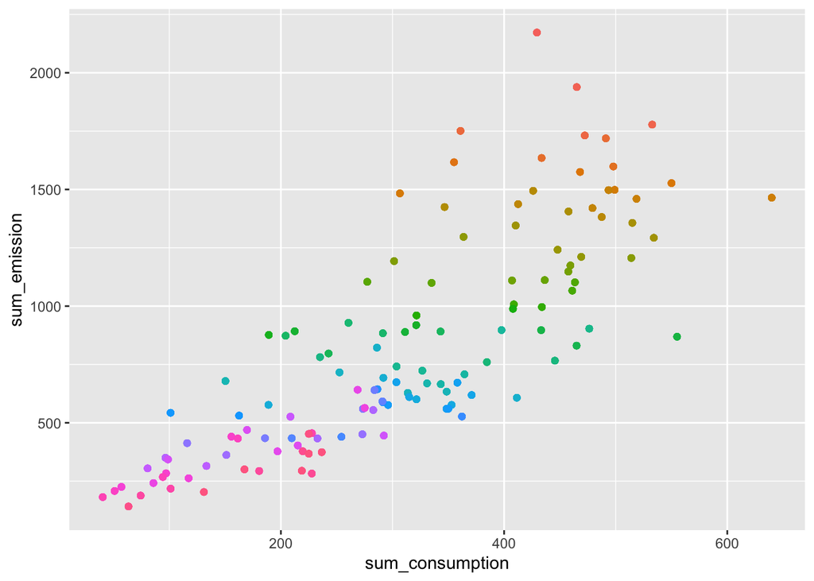

```
e. Faceted graphs: countries that start with "a"--"l" and "m"--"z".
```

```r
table_content_tbl_tidy %>%
  group_by(country) %>%
  mutate(sum_consumption = sum(kg_consumption),
         sum_emission = sum(kg_co2)) %>%
  ggplot() +
  geom_point(aes(x = sum_consumption, y = sum_emission, color = country)) +
  theme(legend.position = "none")
```

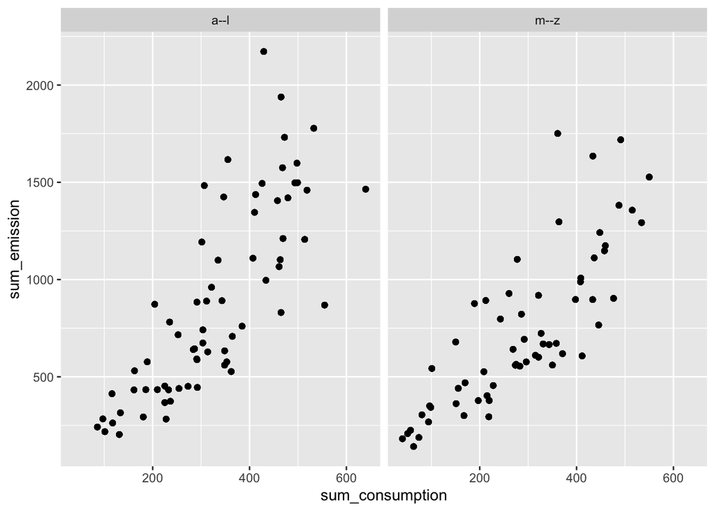

```r
table_content_tbl_tidy %>%
  group_by(country) %>%
  mutate(sum_consumption = sum(kg_consumption),
         sum_emission = sum(kg_co2),
         indicator = case_when(as.character(country) < "m" ~ "a--l",
                               as.character(country) >= "m" ~ "m--z")) %>%
  ggplot() +
  geom_point(aes(x = sum_consumption, y = sum_emission)) +
  facet_wrap(~indicator) +
  theme(legend.position = "none")
```

6. Store your dataset as a csv-file.

```r
# read_csv(table_content_tbl_tidy, "dataset_food_consumption.csv")
```

You work with a tibble, so use means from the `tidyverse` packages and store your data in a tibble. Data manipulations should be performed using the pipe operator. Code for 2–4 can be put in one chunk. If you need some further information, drop me an email with “hint” in it and I will provide you some. Assignment is to be handed in as an RMarkdown (you can build upon this one) and html file until 2020-07-06 via email.

Have fun,  
Felix